# Practical 6 - GLM (Fundamental Techniques in Data Science with R)

Amanda Ferraboli

2023-12-18

## Introduction

In this practical, you will perform regression analyses using `glm()` and inspect variables by plotting these variables, using `ggplot()`.

```r
library(dplyr)
library(magrittr)
library(ggplot2)
library(foreign)
library(kableExtra)
library(janitor)
library(readr)
```

## Logistic regression

The glm() function is used to specify several different models, among which the logistic regression model. The logistic regression model can be specified by setting the family argument to “binomial”. You can save a model in an object and request summary statistics with the summary() command.

For logistic regression, it important to know and check what category the predicted probabilities refer to, so you can interpret the model and it’s coefficients correctly. If your outcome variable is coded as a factor, the glm() function predicts the 2nd category, which is by default the alphabetical latter one. For example, if the categories are coded as 0 and 1, the probability of belonging to “1” is predicted by the model.

## Working with odds and log-odds

Before we get started with logistic modelling it helps to understand how odds, log-odds, and probability are related. Essentially, they are all just different expressions of the same thing and converting between them involve simple formulas.

Coefficients calculated using the glm() function returns log-odds by default. Most of us find it difficult to think in terms of log-odds, so instead we convert them to odds (or odds-ratios) using the exp() function. If we want to go from odds to log-odds, we just take the logarithm using log().

An odds-ratio is the probability of success and is defined as Odds=P/1−P, where P is the probability of an event happening and 1−P is the probability that it does not happen.

The code below creates a data frame called data with a column called conc showing the number of trials wherein different concentrations of the peptide-C protein inhibited the flow of current across a membrane. The yes column contains counts of trials where this occured.

```r
data <- data.frame(conc = c(0.1, 0.5, 1, 10, 20, 30, 50, 70, 80, 100, 150),
                   no = c(7, 1, 10, 9, 2, 9, 13, 1, 1, 4, 3),
                   yes = c(0, 0, 3, 4, 0, 6, 7, 0, 0, 1 ,7)
)

data
```

```
##     conc no yes
## 1    0.1  7   0
## 2    0.5  1   0
## 3    1.0 10   3
## 4   10.0  9   4
## 5   20.0  2   0
## 6   30.0  9   6
## 7   50.0 13   7
## 8   70.0  1   0
## 9   80.0  1   0
## 10 100.0  4   1
## 11 150.0  3   7
```

### Question 1

Add the following variables to the dataset: - the total number of trials for each observation (i.e., the sum of the no and yes trials for each row) - the proportion of yes trials in each row (i.e. yes divided by the total) - the log-odds of inhibition for each row (i.e. the log-odds of yes vs no)

```r
data <- data %>%
  mutate(
  total = no + yes,
  yes_prop = yes / total,
  log_odds = log(yes_prop/(no/total))
)
```

### Question 2

Inspect the new columns. Do you notice anything unusual?

```r
head(data)
```

```
##   conc no yes total  yes_prop   log_odds
## 1  0.1  7   0     7 0.0000000       -Inf
## 2  0.5  1   0     1 0.0000000       -Inf
## 3  1.0 10   3    13 0.2307692 -1.2039728
## 4 10.0  9   4    13 0.3076923 -0.8109302
## 5 20.0  2   0     2 0.0000000       -Inf
## 6 30.0  9   6    15 0.4000000 -0.4054651
```

From the first 6 rows it is possible to see values of infinity in the log-odds column. Zeroes in the proportions of yes trials make the odds-ratio zero, the log of zero is undefined, thus generating infinity. This is a problem because many functions will not work if any input value is infinite. To fix this issue, a constant can be added to the yes/no columns to maintain the difference and relation between them in the odds, but avoid the zeroes in proportion.

### Question 3

Add a new column to your dataset containing the corrected odds. You can compute the value of this column using the following formulation of the log-odds:

log(odds)=log(yes + 0.5/ no + 0.5)

```r
add_constant_log_odds <- function(x, y, constant = 0.5){
  log((x + constant) / (y + constant))
}

data <- data %>%
  mutate(
    log_odds_05 = add_constant_log_odds(yes, no),
    log_odds_1 = add_constant_log_odds(yes, no, constant = 1))

data
```

```
##     conc no yes total  yes_prop   log_odds log_odds_05 log_odds_1
## 1    0.1  7   0     7 0.0000000       -Inf  -2.7080502 -2.0794415
## 2    0.5  1   0     1 0.0000000       -Inf  -1.0986123 -0.6931472
## 3    1.0 10   3    13 0.2307692 -1.2039728  -1.0986123 -1.0116009
## 4   10.0  9   4    13 0.3076923 -0.8109302  -0.7472144 -0.6931472
## 5   20.0  2   0     2 0.0000000       -Inf  -1.6094379 -1.0986123
## 6   30.0  9   6    15 0.4000000 -0.4054651  -0.3794896 -0.3566749
## 7   50.0 13   7    20 0.3500000 -0.6190392  -0.5877867 -0.5596158
## 8   70.0  1   0     1 0.0000000       -Inf  -1.0986123 -0.6931472
## 9   80.0  1   0     1 0.0000000       -Inf  -1.0986123 -0.6931472
## 10 100.0  4   1     5 0.2000000 -1.3862944  -1.0986123 -0.9162907
## 11 150.0  3   7    10 0.7000000  0.8472979   0.7621401  0.6931472
```

Experimenting with a constant of value 0.5 and 1, the constant of 0.5 results in log-odds closer to the original values (`log_odds`).

### Question 4

Fit a logistic regression model where: - `prop` is the outcome - `conc` is the only predictor - the number of total trials per row are used as weights (we need this because a different number of trials can go into defining each observation of `prop`) Interpret the slope estimate.

```r
log_model <- glm(yes_prop ~ conc,
                 family = binomial,
                 weights = total,
                 data = data)

summary(log_model)
```

```
##
## Call:
## glm(formula = yes_prop ~ conc, family = binomial, data = data,
##     weights = total)
##
## Coefficients:
##             Estimate Std. Error z value Pr(>|z|)
## (Intercept) -1.32701    0.33837  -3.922 8.79e-05 ***
## conc         0.01215    0.00496   2.450   0.0143 *
## ---
## Signif. codes:  0 '***' 0.001 '**' 0.01 '*' 0.05 '.' 0.1 ' ' 1
##
## (Dispersion parameter for binomial family taken to be 1)
##
##     Null deviance: 16.683  on 10  degrees of freedom
## Residual deviance: 10.389  on  9  degrees of freedom
## AIC: 30.988
##
## Number of Fisher Scoring iterations: 4
```

The slope estimate for this model is 0.01215, the estimate for the only predictor `conc`. It means one unit increase in `conc` significantly increases the log-odds of inhibition (log-odds of yes vs no) by 0.01215.

To interpret the value in odds instead of log odds, the exponentiation can be used. The results are multiplicative effects.

```r
coef(log_model) %>% exp()
```

```
## (Intercept)        conc
##   0.2652701   1.0122259
```

For every unit increase in `conc`, the odds of inhibition (odds ratio of yes vs no) is 1.0122 higher. As it is a value greater than one, it indicates the effect is positive on inhibition.

## Titanic data

You will work with the titanic data set which you can find in the surfdrive folder, containing information on the fate of passengers on the infamous voyage.

- `Survived`: this is the outcome variable that you are trying to predict, with 1 meaning a passenger survived and 0 meaning they did not
- `Pclass`: this is the ticket class the passenger was travelling on, with 1, 2, and 3 representing 1st, 2nd and 3rd class respectively
- `Age`: this is the age of the passenger in years
- `Sex`: this is the sex of the passenger, either male or female

### Question 5

Read in the data from the “titanic.csv” file, selecting only the variables `Survived`, `Pclass`, `Sex` and `Age`. If necessary, correct the class of the variables.

```r
titanic <- read.csv("titanic.csv")
head(titanic)
```

```
##   Survived Pclass      Age    Sex
## 1        0      3 22.00000   male
## 2        1      1 38.00000 female
## 3        1      3 26.00000 female
## 4        1      1 35.00000 female
## 5        0      3 35.00000   male
## 6        0      3 29.69912   male
```

The variables `Sex`, `Pclass` and `Survived` do not have the appropriate class. From the header of the table it is possible to see `Pclass` and `Survived` are treated as integer variables, when they actually symbolize categories. `Sex` is a character variable and to be correctly used by the model should also be changed. The three variables will be converted to factor variables.

```r
titanic <- titanic %>%
  mutate_at(c("Sex", "Pclass", "Survived"), as.factor)

head(titanic)
```

```
##   Survived Pclass      Age    Sex
## 1        0      3 22.00000   male
## 2        1      1 38.00000 female
## 3        1      3 26.00000 female
## 4        1      1 35.00000 female
## 5        0      3 35.00000   male
## 6        0      3 29.69912   male
```

### Question 6

What relationships do you expect to find between the predictor variables and the outcome?

`Survived` is the outcome variable, it is expected that the higher the `Pclass`, being 1 the first and highest class, the higher is the probability of survival. Concerning `Sex` it is expected that women have a higher probability of surviving. Finally, concerning `Age` the expectation might be ambiguous. There might be a higher probability of children surviving, but there might also have been a priority for elderly people. As of in the beginning of the 1900’s there were not many very old people, the reported expected relation between surviving and age is the younger the passenger, the higher the probability of survival.

### Question 7

Investigate how many passengers survived in each class. You can do this visually by creating a bar plot, or by using the table() function. Search ??table for more information.

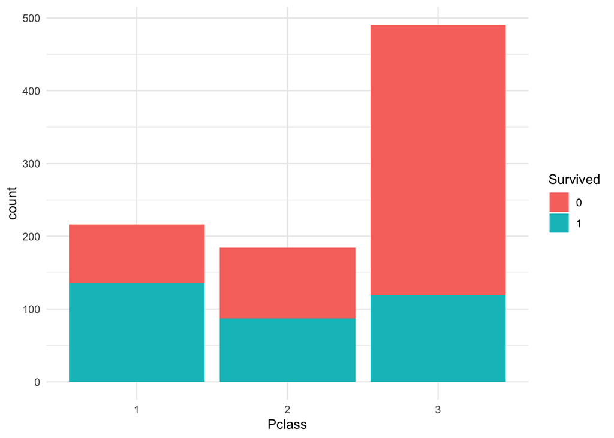

```r
titanic %>%
  ggplot(aes(Pclass, fill = Survived)) +
  geom_bar() +
  theme_minimal()
```

It is possible to improve the plot by unstacking the columns.

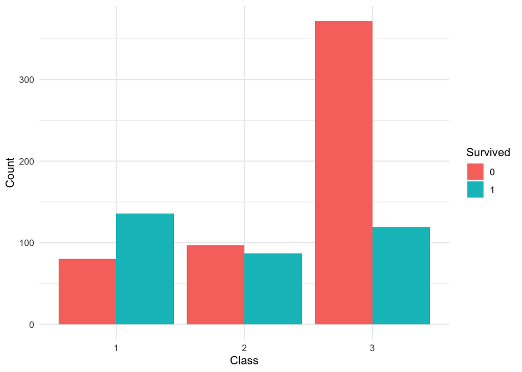

```r
titanic %>%
  ggplot(aes(Pclass, fill = Survived)) +
  geom_bar(position = "dodge") +
  labs(x = "Class",
       y = "Count") +
  theme_minimal()
```

After accounting for the exact number of passengers who survived of not, it is also interesting to understand the relative proportions. The argument position can be used to accomplish this task.

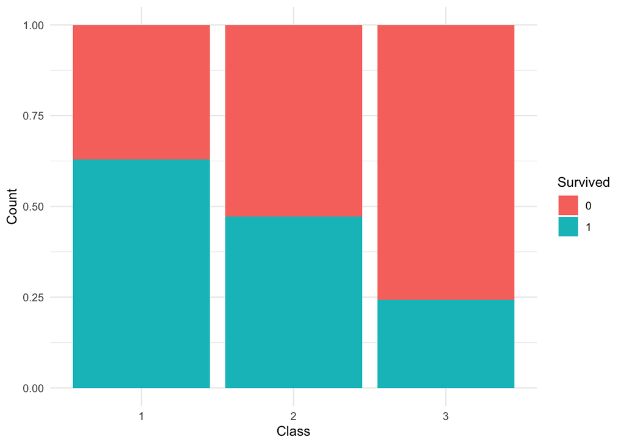

```r
titanic %>%
  ggplot(aes(Pclass, fill = Survived)) +
  geom_bar(position = "fill") +
  labs(x = "Class",
       y = "Count") +
  theme_minimal()
```

From all passengers of 1st class, approximately 62% survived. From 2nd class the survival rate is a bit less than 50%; and for the 3rd class, it is a bit less than 25%.

These numbers can be confirmed by using the `table()` function.

```r
options(digits=3)
prop.table(table(titanic$Pclass, titanic$Survived),
           margin = 1)
```

```
##
##         0     1
##   1 0.370 0.630
##   2 0.527 0.473
##   3 0.758 0.242
```

```r
# margin = 1 uses proportions by row; margin = 2, by column
```

### Question 8

Similarly, investigate the relationship between survival and sex by creating a bar plot and a table.

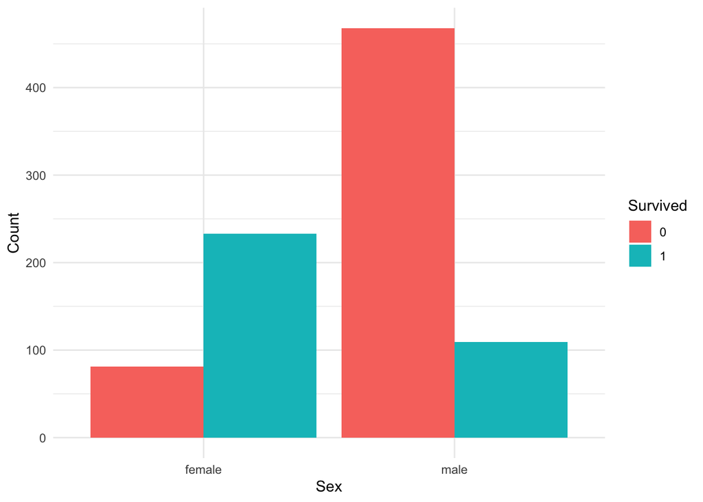

```r
titanic %>%
  ggplot(aes(Sex, fill = Survived)) +
  geom_bar(position = "dodge") +
  labs(x = "Sex",
       y = "Count") +
  theme_minimal()
```

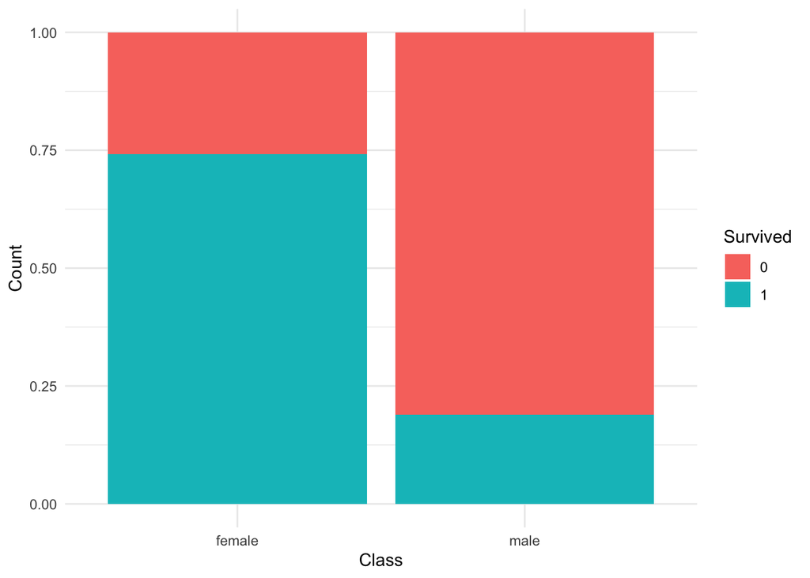

```r
titanic %>%
  ggplot(aes(Sex, fill = Survived)) +
  geom_bar(position = "fill") +
  labs(x = "Class",
       y = "Count") +
  theme_minimal()
```

```r
prop.table(table(titanic$Sex, titanic$Survived),
           margin = 1)
```

```
##
##              0     1
##   female 0.258 0.742
##   male   0.811 0.189
```

```r
# margin = 1 uses proportions by row; margin = 2, by column
```

Both is absolute and in relative terms, women are more likely to survive. Almost 250 women survived, while only 100 men survived. These numbers correspond to a proportion of 74% among women, and 19% among men.

### Question 9

Investigate the relationship between age and survival by creating a histogram of the age of survivors versus non-survivors.

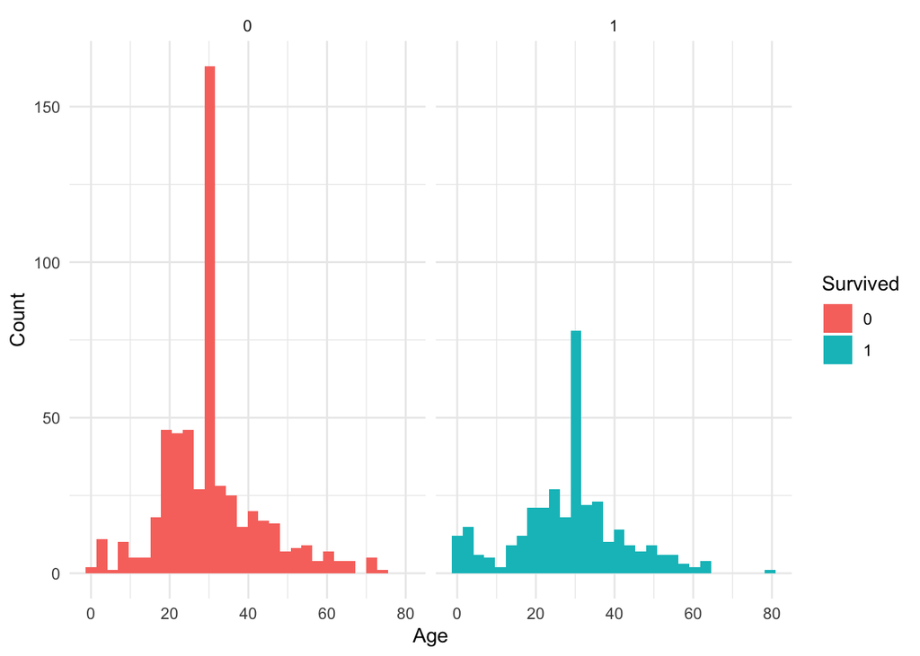

```r
titanic %>%
  ggplot(aes(Age, fill = Survived)) +
  geom_histogram() +
  labs(x = "Age",
       y = "Count") +
  facet_wrap(~Survived) +
  theme_minimal()
```

The distribution of the people who survived, shown in blue in the plot, has a clear concentration on the left tail of the distribution, compared to the red distribution (passengers who did not survive). It means younger people have higher chances of survival compared to passengers of other ages.

## No predictors

### Question 10

Specify a logistic regression model where “Survived” is the outcome and there are no predictors.

```r
no_predictors <- glm(Survived ~ 1,
    family = binomial,
    data = titanic)

summary(no_predictors)
```

```
##
## Call:
## glm(formula = Survived ~ 1, family = binomial, data = titanic)
##
## Coefficients:
##             Estimate Std. Error z value Pr(>|z|)
## (Intercept)  -0.4733     0.0689   -6.87  6.4e-12 ***
## ---
## Signif. codes:  0 '***' 0.001 '**' 0.01 '*' 0.05 '.' 0.1 ' ' 1
##
## (Dispersion parameter for binomial family taken to be 1)
##
##     Null deviance: 1186.7  on 890  degrees of freedom
## Residual deviance: 1186.7  on 890  degrees of freedom
## AIC: 1189
##
## Number of Fisher Scoring iterations: 4
```

A logistic regression without predictors will return only the intercept estimate, it can be compared with more complex models. The estimate for the intercept is -0.4733 and is interpreted as the log-odds of survival for all passengers (all population). The log-odds ratio can be generated from the data to confirm if it indeed matches the value of the estimate.

```r
titanic %>%
count(Survived)
```

```
##   Survived   n
## 1        0 549
## 2        1 342
```

```r
#log-odds survuval = log(odds yes/odds no)
odds_yes <- 342 / (342 + 549)
odds_no <- 549 / (342 + 549)
log_odds_survival <- log(odds_yes/odds_no)

log_odds_survival
```

```
## [1] -0.473
```

The value of the intercept estimate is the log-odds ratio for survival for all passengers.

## Binary predictor

### Question 11

Specify a logistic regression model where “Survived” is the outcome and “Sex” is the only predictor.

```r
sex_predictor_model <- glm(Survived ~ Sex,
    family = binomial,
    data = titanic)

summary(sex_predictor_model)
```

```
##
## Call:
## glm(formula = Survived ~ Sex, family = binomial, data = titanic)
##
## Coefficients:
##             Estimate Std. Error z value Pr(>|z|)
## (Intercept)    1.057      0.129    8.19  2.6e-16 ***
## Sexmale       -2.514      0.167  -15.04  < 2e-16 ***
## ---
## Signif. codes:  0 '***' 0.001 '**' 0.01 '*' 0.05 '.' 0.1 ' ' 1
##
## (Dispersion parameter for binomial family taken to be 1)
##
##     Null deviance: 1186.7  on 890  degrees of freedom
## Residual deviance:  917.8  on 889  degrees of freedom
## AIC: 921.8
##
## Number of Fisher Scoring iterations: 4
```

### Question 12

What does the intercept mean? What are the odds and what are the log-odds of survival for males?

The intercept corresponds to the log-odds of survival for women (the reference group), it is 1.057

The log-odds survival for males is -2.514 lower than for women. To estimate the odds of survival, one can exponentiate the log-odds.

```r
exp(sex_predictor_model$coefficients)
```

```
## (Intercept)     Sexmale
##       2.877       0.081
```

```r
1 - 0.081
```

```
## [1] 0.919
```

The odds of survival for males is 0.081, 92% lower than females.

## Categorical predictor (more than 2 categories)

### Question 13

Specify a logistic regression model where “Survived” is the outcome and “Pclass” is the only predictor.

```r
cat_predictor_model <- glm(Survived ~ Pclass,
    family = binomial,
    data = titanic)

summary(cat_predictor_model)
```

```
##
## Call:
## glm(formula = Survived ~ Pclass, family = binomial, data = titanic)
##
## Coefficients:
##             Estimate Std. Error z value Pr(>|z|)
## (Intercept)    0.531      0.141    3.77  0.00017 ***
## Pclass2       -0.639      0.204   -3.13  0.00173 **
## Pclass3       -1.670      0.176   -9.50  < 2e-16 ***
## ---
## Signif. codes:  0 '***' 0.001 '**' 0.01 '*' 0.05 '.' 0.1 ' ' 1
##
## (Dispersion parameter for binomial family taken to be 1)
##
##     Null deviance: 1186.7  on 890  degrees of freedom
## Residual deviance: 1083.1  on 888  degrees of freedom
## AIC: 1089
##
## Number of Fisher Scoring iterations: 4
```

### Question 14

Which category is the reference group? What are their odds of survival?

The reference group is the first class, the class for which a dummy is not created and is represented in the intercept estimate. The log-odds of survival for first class passengers is 0.531.

```r
exp(cat_predictor_model$coefficients)
```

```
## (Intercept)     Pclass2     Pclass3
##       1.700       0.528       0.188
```

### Question 15

What are the chances of survival for 2nd and 3rd class passengers?

## Continuous predictor

### Question 16

Specify a logistic regression model where “Survived” is the outcome and “Age” is the only predictor.

```r
cont_predictor_model <- glm(Survived ~ Age,
    family = binomial,
    data = titanic)

summary(cont_predictor_model)
```

```
##
## Call:
## glm(formula = Survived ~ Age, family = binomial, data = titanic)
##
## Coefficients:
##             Estimate Std. Error z value Pr(>|z|)
## (Intercept) -0.14327    0.17209   -0.83    0.405
## Age         -0.01120    0.00539   -2.08    0.038 *
## ---
## Signif. codes:  0 '***' 0.001 '**' 0.01 '*' 0.05 '.' 0.1 ' ' 1
##
## (Dispersion parameter for binomial family taken to be 1)
##
##     Null deviance: 1186.7  on 890  degrees of freedom
## Residual deviance: 1182.3  on 889  degrees of freedom
## AIC: 1186
##
## Number of Fisher Scoring iterations: 4
```

```r
exp(cont_predictor_model$coefficients)
```

```
## (Intercept)         Age
##       0.867       0.989
```

### Question 17

What does the intercept mean when there is a continuous predictor?

The intercept when the predictors are continuous represent the log-odds of when all predictors have a value of zero. In the case of the model above, the intercept of -0.14327 represents the log-odds of survival when age is zero.

### Question 18

How are the odds and log-odds interpreted for a continuous predictor?

In the case of a continuous predictor, for every unit increase in the predictor the log-odds for the outcome increase or decrease. This log-odd can be exponentiated to generate the odds. In the case of the estimated model above, for every increase of one year of age, the log odds are lower by -0.011 and the chances of survival decrease. Likewise, for every increase of one year of age, the odds are 0.989, or 1.1% lower, if compared to passengers with one year less.

## Multinomial model with an interaction term

### Question 19

Specify a logistic regression model Survived is the outcome and Pclass plus an interaction between Sex and Age as the predictor. Save this model as we will return to it later.

```r
interaction_model <- glm(Survived ~ Pclass + Sex*Age,
    family = binomial,
    data = titanic)

summary(interaction_model)
```

```
##
## Call:
## glm(formula = Survived ~ Pclass + Sex * Age, family = binomial,
##     data = titanic)
##
## Coefficients:
##             Estimate Std. Error z value Pr(>|z|)
## (Intercept)   2.8343     0.4150    6.83  8.5e-12 ***
## Pclass2      -1.2644     0.2732   -4.63  3.7e-06 ***
## Pclass3      -2.4126     0.2500   -9.65  < 2e-16 ***
## Sexmale      -1.2629     0.4334   -2.91  0.00357 **
## Age          -0.0042     0.0114   -0.37  0.71308
## Sexmale:Age  -0.0485     0.0146   -3.32  0.00088 ***
## ---
## Signif. codes:  0 '***' 0.001 '**' 0.01 '*' 0.05 '.' 0.1 ' ' 1
##
## (Dispersion parameter for binomial family taken to be 1)
##
##     Null deviance: 1186.66  on 890  degrees of freedom
## Residual deviance:  793.82  on 885  degrees of freedom
## AIC: 805.8
##
## Number of Fisher Scoring iterations: 5
```

### Question 20

How is the significant interaction term interpreted in this model? The interaction term is testing if the effect of age on survival is different in men and women. The result is a significant term, which means the slopes for survival (y) on age are significantly different for each level of sex.

## Model fit

Model selection is an important step and there are several metrics for assessing model fit to help us select the best performing model. We will use deviance and information criterion to compare the fit of two models you saved before: fit1 and fit2.

### Deviance

Deviance is measure of the goodness-of-fit in a GLM where lower deviance indicates a better fitting model. R reports two types of deviance:

- null deviance: how well the outcome is predicted by the intercept-only model
- residual deviance: how well the outcome is predicted by the model with the predictors added

### Question 21

Get the model summaries and indicate what the null and residual deviance are.

```r
summary(cont_predictor_model)
```

```
##
## Call:
## glm(formula = Survived ~ Age, family = binomial, data = titanic)
##
## Coefficients:
##             Estimate Std. Error z value Pr(>|z|)
## (Intercept) -0.14327    0.17209   -0.83    0.405
## Age         -0.01120    0.00539   -2.08    0.038 *
## ---
## Signif. codes:  0 '***' 0.001 '**' 0.01 '*' 0.05 '.' 0.1 ' ' 1
##
## (Dispersion parameter for binomial family taken to be 1)
##
##     Null deviance: 1186.7  on 890  degrees of freedom
## Residual deviance: 1182.3  on 889  degrees of freedom
## AIC: 1186
##
## Number of Fisher Scoring iterations: 4
```

```r
summary(interaction_model)
```

```
##
## Call:
## glm(formula = Survived ~ Pclass + Sex * Age, family = binomial,
##     data = titanic)
##
## Coefficients:
##             Estimate Std. Error z value Pr(>|z|)
## (Intercept)   2.8343     0.4150    6.83  8.5e-12 ***
## Pclass2      -1.2644     0.2732   -4.63  3.7e-06 ***
## Pclass3      -2.4126     0.2500   -9.65  < 2e-16 ***
## Sexmale      -1.2629     0.4334   -2.91  0.00357 **
## Age          -0.0042     0.0114   -0.37  0.71308
## Sexmale:Age  -0.0485     0.0146   -3.32  0.00088 ***
## ---
## Signif. codes:  0 '***' 0.001 '**' 0.01 '*' 0.05 '.' 0.1 ' ' 1
##
## (Dispersion parameter for binomial family taken to be 1)
##
##     Null deviance: 1186.66  on 890  degrees of freedom
## Residual deviance:  793.82  on 885  degrees of freedom
## AIC: 805.8
##
## Number of Fisher Scoring iterations: 5
```

The null deviance does not change between the models, it is 1186.7 in the first model and 1186.66 in the model with interaction. The residual is 1182.3 in the first model and decreases to 793.82 in the model with interaction.

We can use the anova() function to perform an analysis of deviance that compares the difference in deviances between competing models.

### Question 22

Compare the fit of model 1 with the fit of model 2 using anova() and test = “Chisq”`.

```r
anova(cont_predictor_model, interaction_model, test = "Chisq")
```

```
## Analysis of Deviance Table
##
## Model 1: Survived ~ Age
## Model 2: Survived ~ Pclass + Sex * Age
##   Resid. Df Resid. Dev Df Deviance Pr(>Chi)
## 1       889       1182
## 2       885        794  4      388   <2e-16 ***
## ---
## Signif. codes:  0 '***' 0.001 '**' 0.01 '*' 0.05 '.' 0.1 ' ' 1
```

The analysis of deviance can compare the differences in deviance for the models and test for its significance. It is possible to see in the table the reduction in residual deviance of 388 from model 1 to model with interaction. That difference is statistically significant and indicates a better fit of the model with the interaction term (model 2).

### Information criteria

AIC is the Akaike’s Information Criterion, a method for assessing model quality through comparison of related models. AIC is based on the deviance but introduces a penalty for more complex models. The number itself is not meaninful, and it is only useful when comparing models against one another. Like deviance, the model with the lowest AIC is best.

### Question 23

Use the AIC() function to get the AIC value for model 1 and model 2.

```r
AIC(cont_predictor_model, interaction_model)
```

```
##                      df  AIC
## cont_predictor_model  2 1186
## interaction_model     6  806
```

The AIC for the model with interaction term (model 2) is lower, an indication of better fit than the first model.

BIC is the Bayesian Information Criterion and is very similar to AIC, but penalises a complex model more than the AIC would. Complex models will have a larger score indicating worse fit. One difference to the AIC is that the probability of selecting the correct model with the BIC increases as the sample size of the training set increases.

### Question 24

Use the BIC() function to get the BIC value for model 1 and model 2.

```r
BIC(cont_predictor_model, interaction_model)
```

```
##                      df  BIC
## cont_predictor_model  2 1196
## interaction_model     6  835
```

The BIC for the model with interaction term (model 2) is lower, an indication of better fit than the first model.

### Question 25

Which model should we proceed with? Model 2, with the interaction term should be picked since it has a statistically significant lower residual deviance, lower AIC and lower BIC.

## Predicted probabilites

### Question 26

Use the predict() function to generate predicted probabilities for the multivariate logistic model. predict() takes the following arguments: - object, i.e. the logistic model - newdata, i.e. a data set where we want to predict the outcome (we will use titanic) - type, i.e. can be “logit” for log-odds or “response” for probabilities (we will use type = “response”) - se.fit, i.e. set to TRUE to estimate the standard error of the probabilities Remember to save the output to an object.

```r
predictions <- data.frame(predict(object = interaction_model,
                                  newdata = titanic,
                                  type = "response",
                                  se.fit = TRUE))
```

### Question 27

Add the predicted probabilities and standard errors to the data set.

```r
# inspect arguments available by typing model + $
titanic$pred_probs <- predictions$fit
titanic$se    <- predictions$se.fit
```

### Question 28

Calculate the confidence intervals for the predicted probabilities and add them to the data.

```r
titanic <- titanic %>%
  mutate(ci_lower = pred_probs - 1.96 * se,
         ci_upper = pred_probs + 1.96 * se)
head(titanic)
```

```
##   Survived Pclass  Age    Sex pred_probs     se ci_lower ci_upper
## 1        0      3 22.0   male     0.1192 0.0170   0.0859    0.153
## 2        1      1 38.0 female     0.9355 0.0164   0.9034    0.968
## 3        1      3 26.0 female     0.5775 0.0371   0.5047    0.650
## 4        1      1 35.0 female     0.9363 0.0155   0.9058    0.967
## 5        0      3 35.0   male     0.0639 0.0113   0.0418    0.086
## 6        0      3 29.7   male     0.0828 0.0127   0.0580    0.108
```

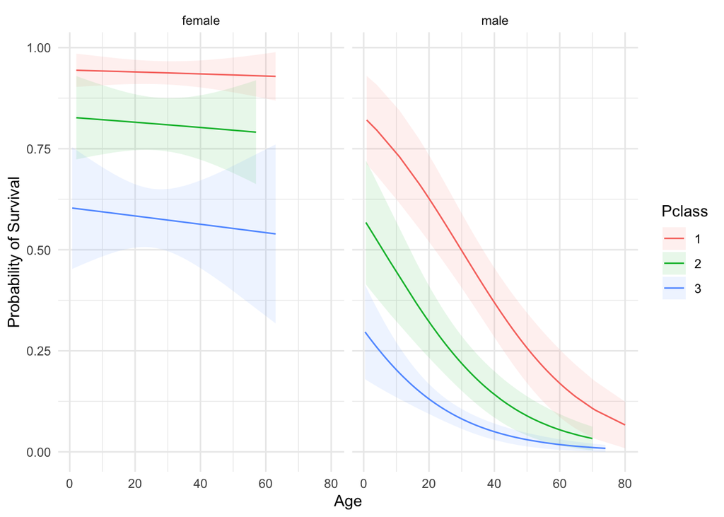

```r
  ggplot(aes(x = Age, y = pred_probs), data = titanic) +
    geom_ribbon(aes(ymin = ci_lower, ymax = ci_upper, fill = Pclass), alpha = 0.1) +
    geom_line(aes(color = Pclass)) +
    labs(y = "Probability of Survival",
         x = "Age") +
    theme_minimal() +
    facet_wrap(vars(Sex))
```